# Bank Marketing Data Notebook

- The Project
  - Business Problem
  - Methodology
- About the Dataset
  - Inputs
- Exploratory Data Analysis
  - Categorical Features
  - Continuous Features
- Data Pipeline & Preprocessing
  - Baseline
  - Feature Engineering
- Modeling
  - Tuning Models
  - Training Best Model
  - Feature Importance
  - Saving Model
- Conclusion

## The Project

This notebook documents the Data Science process for the **Tech Challenge 3** belonging to FIAP's Machine Learning Engineering PostGrad program.  
In this project we will use the [Bank Marketing dataset](https://archive.ics.uci.edu/dataset/222/bank+marketing) available at the UC Irvine Machine Learning Repository to build a model using **supervised learning techniques for classification tasks.**

### Business Problem

A bank wants to improve the efficiency of its telemarketing campaigns for term deposits. Our goal is to create a machine learning model that can predict which clients are more likely to subscribe, allowing the bank to focus its efforts on the most promising leads, increasing the success rate and reducing marketing costs.

### Methodology

This project follows a structured Machine Learning Workflow:

1. **Exploratory Data Analysis:** We will analyze the dataset to understand distributions, find patterns, and form our initial hypotheses.  
   2.**Data Pipeline & Preprocessing:** We will build a simple classification model using *Logistic Regression* to build a baseline to compare our more complex models with. In this stage, we will also clean the data and engineer features based on insights from the exploratory analysis.
2. **Modeling & Comparison:** We will evaluate a suite of classifiers using cross-validation. Based on performance, we will select a few models for hyperparameter tuning with Optuna to extract the best performance possible.
3. **Conclusion:** In the conclusion, we will provide a final overview of our discoveries, models, and methodology, focusing on how this project can help with the solution of the business problem.

## About the Dataset

The data is related to direct marketing campaigns of a Portuguese banking institution. These campaigns were primarily conducted via phone calls, and often, more than one contact to the same client was required to determine if the product (*a bank term deposit*) would be subscribed to.  
The classification goal of this project is to predict if a client will subscribe (`yes` or `no`) to a term deposit, which is our target variable, `y`.

To better understand the content of this dataset, we listed below the variable names, types, and description, as found in the variables table provided on the official UC Irvine Machine Learning Repository:

| Variable Name | Type | Description |
| --- | --- | --- |
| age | Integer | The person's age. |
| job | Categorical | Type of job (e.g., `admin`, `services`, etc.). |
| marital | Categorical | Marital status (e.g., `divorced`, `married`, etc.). |
| education | Categorical | Educational level (e.g., `high.school`, `university.degree`, etc.). |
| default | Binary | Has credit in default? |
| balance | Integer | Average yearly balance. |
| housing | Binary | Has housing loan? |
| loan | Binary | Has personal loan? |
| contact | Categorical | Contact communication type (e.g., `cellular`, `telephone`). |
| day_of_week | Date | Day of the week when the last contact was made. |
| month | Date | The month when the last contact was made. |
| duration | Integer | The duration, in seconds, of the last contact made. |
| campaign | Integer | Number of contacts performed during this campaing for this specific client, including the last contact. |
| pdays | Integer | Number of days that have passed by after the client was last contacted from a previous campaign (`-1` means client was **not** previously contacted). |
| previous | Integer | Number of contacts performed for this client before this campaign. |
| poutcome | Categorical | Outcome of the previous marketing campaign (`success`, `failure`, etc.) |
| y | Binary | **Target variable**. It answers if the client has subscribed to a term deposit. |

```python
# Importing libraries
import pandas as pd
import numpy as np
import matplotlib.pyplot as plt
import seaborn as sns
import matplotlib.patches as mpatches
import time
import optuna
import joblib
import os
from sklearn.model_selection import train_test_split, StratifiedKFold, cross_validate, cross_val_score
from sklearn.compose import ColumnTransformer
from sklearn.preprocessing import OneHotEncoder, PowerTransformer
from sklearn.linear_model import LogisticRegression
from sklearn.ensemble import (RandomForestClassifier, GradientBoostingClassifier,
                              StackingClassifier, VotingClassifier, HistGradientBoostingClassifier)
from lightgbm import LGBMClassifier
from xgboost import XGBClassifier
from sklearn.metrics import (confusion_matrix, precision_score, recall_score,
                             f1_score, roc_auc_score, RocCurveDisplay, classification_report)
from imblearn.over_sampling import SMOTE
from imblearn.pipeline import Pipeline as ImbPipeline
import warnings
warnings.filterwarnings('ignore')

# Settings and configurations
sns.set_style('whitegrid')
pd.set_option('display.max_columns', None)
```

```python
# Defining seed for reproducibility
seed = 42
```

## Exploratory Data Analysis

In this section, we'll conduct an EDA to understand the dataset. Our goal is to assess data quality, check missing values, and understand the relationship between features and the target variable. The insights gained here will be critical for guiding our feature engineering and modeling strategies in the next stages.

```python
# Defining functions for EDA
def display_feature_list(features, feature_type):
    '''
    This function displays the features within each list for each type of data
    '''

    print(f"\n{feature_type} Features: ")
    print(', '.join(features) if features else 'None')


def describe_df(df):
    """
    This function prints some basic info on the dataset and
    sets global variables for feature lists.
    """

    global categorical_features, continuous_features, binary_features
    categorical_features = [
        col for col in df.columns if df[col].dtype == 'object']
    binary_features = [col for col in df.columns if df[col].nunique(
    ) <= 2 and df[col].dtype != 'object']
    continuous_features = [
        col for col in df.columns if df[col].dtype != 'object' and col not in binary_features]

    print(f"\n{type(df).__name__} shape: {df.shape}")
    print(f"\n{df.shape[0]:,.0f} samples")
    print(f"\n{df.shape[1]:,.0f} attributes")
    display_feature_list(categorical_features, 'Categorical')
    display_feature_list(continuous_features, 'Continuous')
    display_feature_list(binary_features, 'Binary (0 or 1)')
    print(f'\nData Types: \n{df.dtypes}')
    print(
        f'\nMissing Data Percentage: \n{(df.isnull().sum() / len(df) * 100).round(2).astype(str) + "%"}')
    print(f'\nDuplicates: {df.duplicated().sum()}')
    print(
        f'\nCategorical Feature Cardinality: \n{df[categorical_features].nunique().sort_values(ascending=False)}')
    print(
        f'\nFeatures with Zero Variance: {", ".join([col for col in df.columns if df[col].nunique() == 1]) if any(df[col].nunique() == 1 for col in df.columns) else "None"}')

    negative_valued_features = [
        col for col in df[continuous_features] if (df[col] < 0).any()]
    print(
        f'\nFeatures with Negative Values: {", ".join(negative_valued_features) if negative_valued_features else "None"}')

    print('\nStatistical Summary: \n')
    display(df.describe().T)
    print(f'\n{type(df).__name__} Head: \n')
    display(df.head(5))
    print(f'\n{type(df).__name__} Tail: \n')
    display(df.tail(5))
```

```python
# Loading the dataset
df = pd.read_csv('../data/raw/bank_marketing.csv')
describe_df(df)
```

```
DataFrame shape: (45211, 17)

45,211 samples

17 attributes

Categorical Features:
job, marital, education, default, housing, loan, contact, month, poutcome, y

Continuous Features:
age, balance, day_of_week, duration, campaign, pdays, previous

Binary (0 or 1) Features:
None

Data Types:
age             int64
job            object
marital        object
education      object
default        object
balance         int64
housing        object
loan           object
contact        object
day_of_week     int64
month          object
duration        int64
campaign        int64
pdays           int64
previous        int64
poutcome       object
y              object
dtype: object

Missing Data Percentage:
age              0.0%
job             0.64%
marital          0.0%
education       4.11%
```

[output cut: 20 more lines]

```
marital       3
education     3
poutcome      3
default       2
housing       2
loan          2
contact       2
y             2
dtype: int64

Features with Zero Variance: None

Features with Negative Values: balance, pdays

Statistical Summary:
```

|  | count | mean | std | min | 25% | 50% | 75% | max |
| --- | --- | --- | --- | --- | --- | --- | --- | --- |
| age | 45211.0 | 40.936210 | 10.618762 | 18.0 | 33.0 | 39.0 | 48.0 | 95.0 |
| balance | 45211.0 | 1362.272058 | 3044.765829 | -8019.0 | 72.0 | 448.0 | 1428.0 | 102127.0 |
| day_of_week | 45211.0 | 15.806419 | 8.322476 | 1.0 | 8.0 | 16.0 | 21.0 | 31.0 |
| duration | 45211.0 | 258.163080 | 257.527812 | 0.0 | 103.0 | 180.0 | 319.0 | 4918.0 |
| campaign | 45211.0 | 2.763841 | 3.098021 | 1.0 | 1.0 | 2.0 | 3.0 | 63.0 |
| pdays | 45211.0 | 40.197828 | 100.128746 | -1.0 | -1.0 | -1.0 | -1.0 | 871.0 |
| previous | 45211.0 | 0.580323 | 2.303441 | 0.0 | 0.0 | 0.0 | 0.0 | 275.0 |

```
DataFrame Head:
```

|  | age | job | marital | education | default | balance | housing | loan | contact | day_of_week | month | duration | campaign | pdays | previous | poutcome | y |
| --- | --- | --- | --- | --- | --- | --- | --- | --- | --- | --- | --- | --- | --- | --- | --- | --- | --- |
| 0 | 58 | management | married | tertiary | no | 2143 | yes | no | NaN | 5 | may | 261 | 1 | -1 | 0 | NaN | no |
| 1 | 44 | technician | single | secondary | no | 29 | yes | no | NaN | 5 | may | 151 | 1 | -1 | 0 | NaN | no |
| 2 | 33 | entrepreneur | married | secondary | no | 2 | yes | yes | NaN | 5 | may | 76 | 1 | -1 | 0 | NaN | no |
| 3 | 47 | blue-collar | married | NaN | no | 1506 | yes | no | NaN | 5 | may | 92 | 1 | -1 | 0 | NaN | no |
| 4 | 33 | NaN | single | NaN | no | 1 | no | no | NaN | 5 | may | 198 | 1 | -1 | 0 | NaN | no |

```
DataFrame Tail:
```

|  | age | job | marital | education | default | balance | housing | loan | contact | day_of_week | month | duration | campaign | pdays | previous | poutcome | y |
| --- | --- | --- | --- | --- | --- | --- | --- | --- | --- | --- | --- | --- | --- | --- | --- | --- | --- |
| 45206 | 51 | technician | married | tertiary | no | 825 | no | no | cellular | 17 | nov | 977 | 3 | -1 | 0 | NaN | yes |
| 45207 | 71 | retired | divorced | primary | no | 1729 | no | no | cellular | 17 | nov | 456 | 2 | -1 | 0 | NaN | yes |
| 45208 | 72 | retired | married | secondary | no | 5715 | no | no | cellular | 17 | nov | 1127 | 5 | 184 | 3 | success | yes |
| 45209 | 57 | blue-collar | married | secondary | no | 668 | no | no | telephone | 17 | nov | 508 | 4 | -1 | 0 | NaN | no |
| 45210 | 37 | entrepreneur | married | secondary | no | 2971 | no | no | cellular | 17 | nov | 361 | 2 | 188 | 11 | other | no |

- **Missing Data:** The dataset contains significant missing values that we must investigate further.
  - The `poutcome` feature is the most extreme case, with over 80% of its data missing.
  - The variables `contact`, `education`, and `job` also have a notable number of nulls that will require attention.
- **Feature Interpretation**
  - We have reasons to believe that the column `day_of_week` is mislabeled, given it ranges from 1 to 31, signaling it refers to the day of the month, instead of day of the week.
  - We can see that many numerical features, such as `balance`, `campaign`, and `duration`, are heavily right-skewed, indicating that transformations will be necessary before feeding them to our baseline model. That's because linear models, like Logistic Regression, are very sensitive to the scale of the data and can become biased towards values that are far away from the rest of the data.
- **Data Leakage**
  - Feature `duration` represents a data leak. Its value is *unknown* before a call is made, so it must be dropped from our dataset before building our models.

### Categorical Features

Our data has a set of both categorical and continuous features. Let's first focus on the categorical features. We will start by analyzing the distribution of the target variable `y` and then see how the subscription rate varies across different categories.

```python
# EDA Plots
def plot_stacked_bar_percentage(df, feat, target, positive_class='yes'):
    """
    This function plots a 100% stacked bar chart to show the relationship
    between a categorical feature and a binary target variable, including missing values.
    Bars are sorted by the percentage of the positive class.
    """
    palette = ['#29788E', '#E85B5B']

    feature_data = df[feat].fillna('Missing')

    ct = pd.crosstab(feature_data, df[target], normalize='index')

    ct = ct.sort_values(by=positive_class, ascending=False)

    ax = ct.plot(
        kind='barh',
        stacked=True,
        color=palette,
        figsize=(12, 8),
        legend=False
    )

    fig = ax.get_figure()
    fig.set_facecolor('#f5f7f6')
    ax.set_facecolor('#f5f7f6')
    ax.tick_params(axis='x', colors='#555555')
    ax.tick_params(axis='y', colors='#555555')

    for p in ax.patches:
        width = p.get_width()
        height = p.get_height()
        x, y = p.get_xy()
        if width > 0:
            ax.text(
                x + width / 2,
                y + height / 2,
                f'{width:.1%}',
                ha='center',
                va='center',
                color='white',
                fontsize=12,
                fontweight='bold'
            )

    ax.set_title(
        f"Proportion of '{target}' by '{feat}'",
        fontsize=18, fontweight='bold', pad=20, loc='left', color='#333333'
    )
    ax.set_xlabel(
        'Proportion', fontweight='bold', color='#555555'
    )
    ax.set_ylabel(
        feat.title(), fontweight='bold', color='#555555'
    )

    ax.legend(
        title=target.title(),
        bbox_to_anchor=(1.02, 1),
        loc='upper left',
    )

    ax.xaxis.set_major_formatter(plt.FuncFormatter('{:.0%}'.format))
    ax.invert_yaxis()

    sns.despine(left=True, bottom=True)
    plt.tight_layout()
    plt.show()
```

```python
# EDA Plots
def plot_donut(df, feat):
    """
    This function plots a donut chart to show the distribution of a categorical feature.
    """
    counts = df[feat].value_counts()
    labels = counts.index
    values = counts.values

    palette = {
        'no': '#29788E',
        'yes': '#E85B5B'
    }
    colors = [palette.get(label, '#CCCCCC') for label in labels]

    plt.style.use('seaborn-v0_8-whitegrid')
    fig, ax = plt.subplots(figsize=(10,8))
    fig.set_facecolor('#f5f7f6')

    wedges, texts, autotexts = ax.pie(
        values,
        autopct='%1.1f%%',
        startangle=90,
        colors=colors,
        pctdistance=0.85,
        textprops={'fontsize': 12, 'fontweight': 'bold', 'color': 'white'}
    )

    center_circle = plt.Circle((0,0),0.70,fc='#f5f7f6')
    ax.add_artist(center_circle)

    total = df[feat].count()
    ax.text(
        0,0,
        f'Total:\n{total:,}',
        ha='center',
        va='center',
        fontsize=20,
        fontweight='bold',
        color='#555555'
    )

    ax.set_title(
        f"Proportion of Target Variable: '{feat}'",
        fontsize=18, fontweight='bold', pad=20, loc='center', color='#333333'
    )

    ax.axis('equal')

    ax.legend(
        wedges,
        labels,
        title=feat.title(),
        loc='upper right'
    )
    plt.tight_layout()
    plt.show()
```

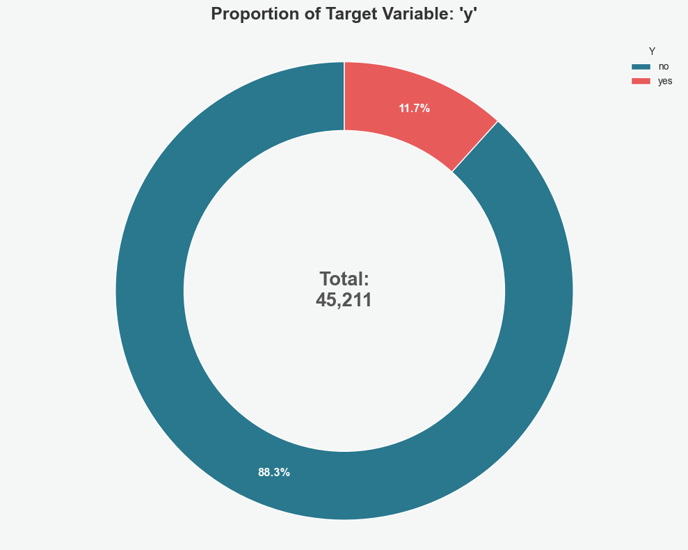

```python
# Obtaining the proportion of labels in the target variable
plot_donut(df, 'y')
```

- **Class Distribution**
  - The chart above shows that our dataset is **highly imbalanced**, meaning that both classes are **not** represented equally. The negative class `no` is the overwhelming majority, accounting for 88.3% (39,922 instances) of a total of 45,211 samples. The `yes` class, on the other hand, accounts for a small minority of 5,289 instances (11.7% of the total).
  - Given this context, a lazy model could achieve 88.3% accuracy by simply predicting *'no'* every single time. `Accuracy` will be a misleading metric.
- **Dealing with Imblanced Labels**
  - Considering the class imbalance, we must focus on other metrics besides accuracy. We must also use the right strategy to deal with imbalance, such as defining the `class_weight='balanced'` param in our models or use techniques like SMOTE to oversample the minority class.

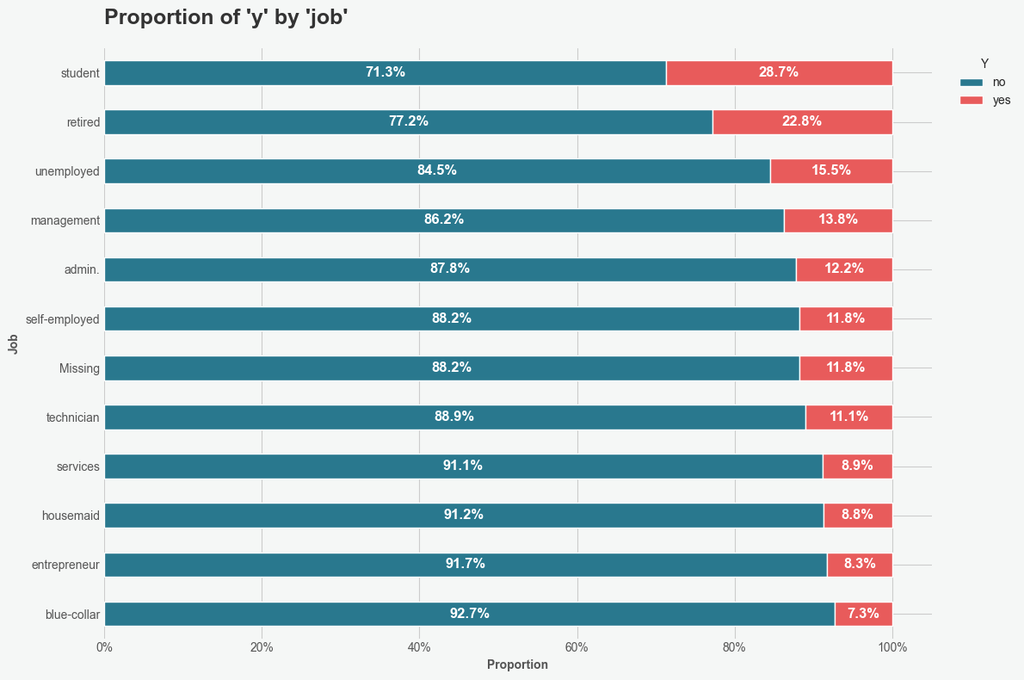

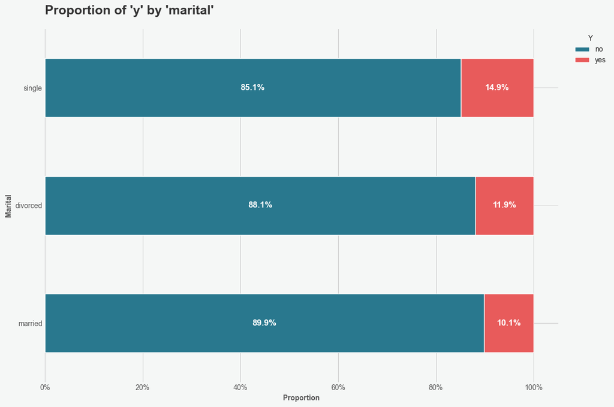

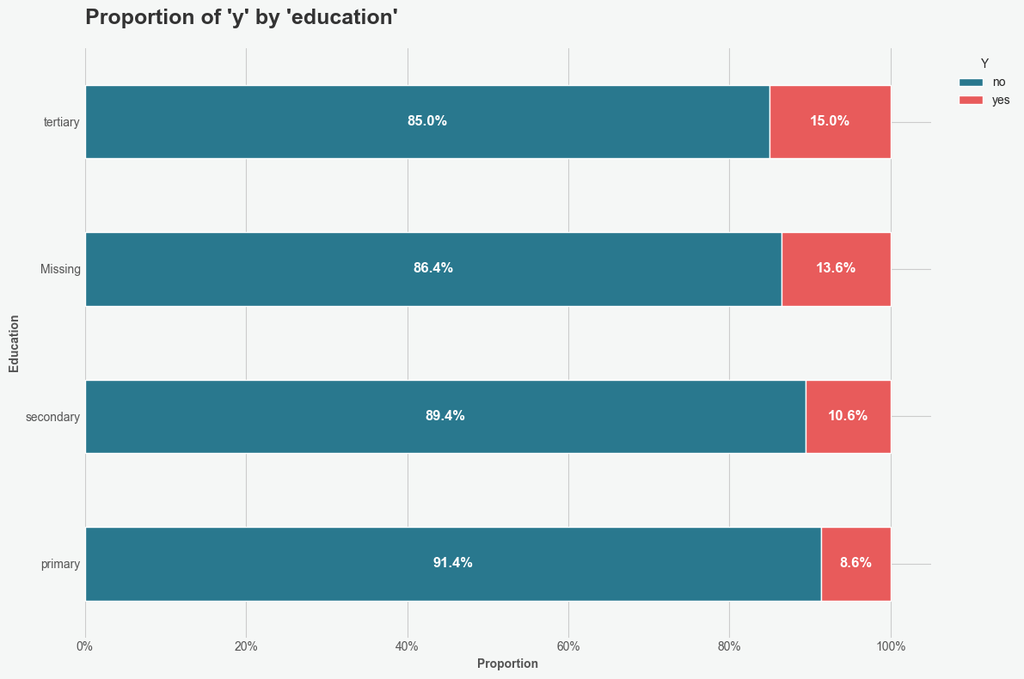

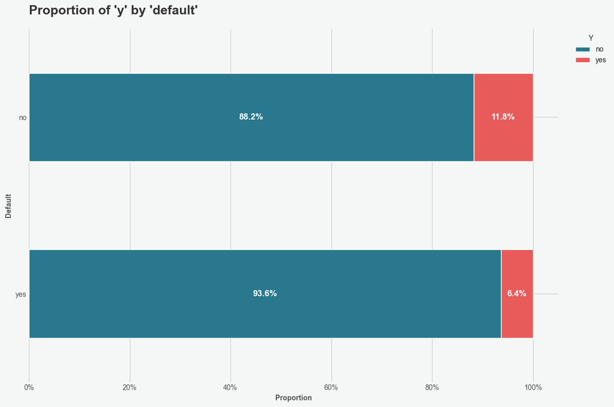

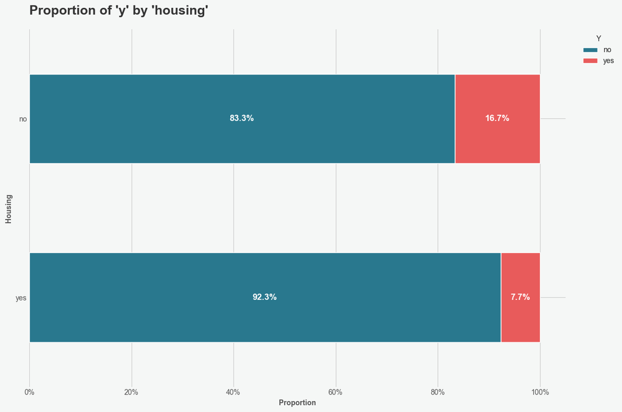

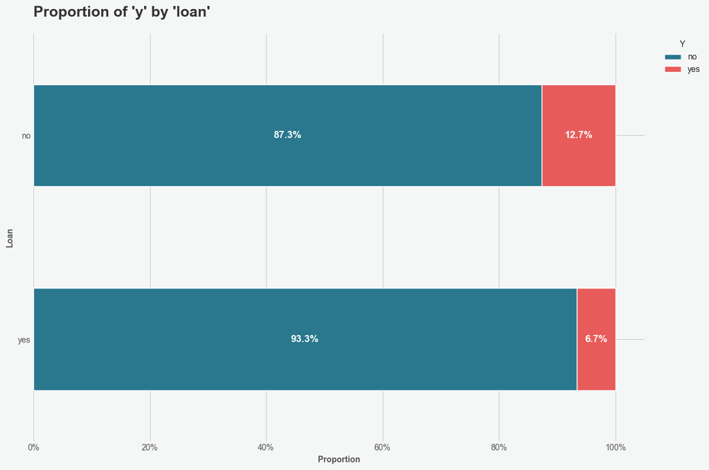

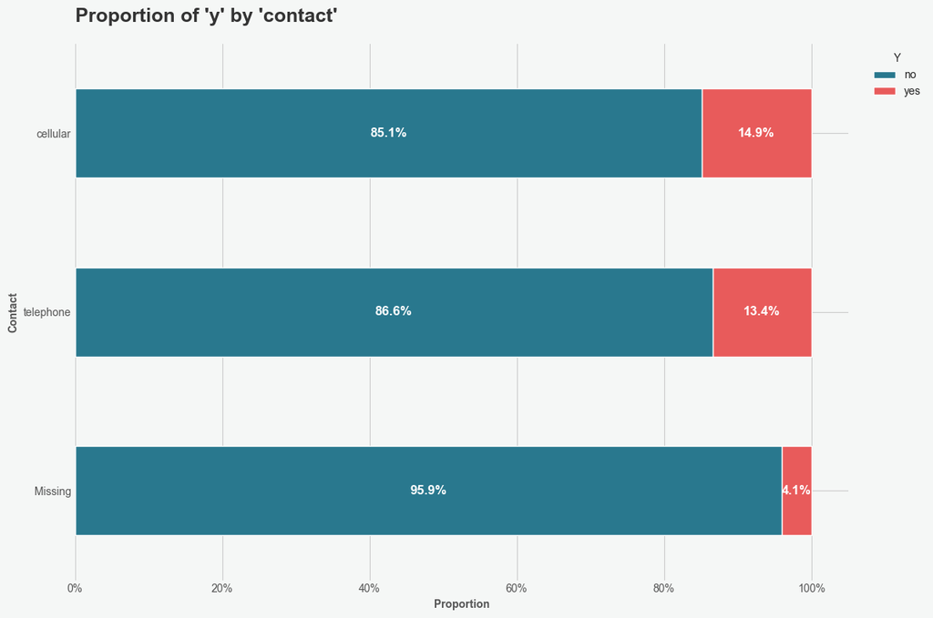

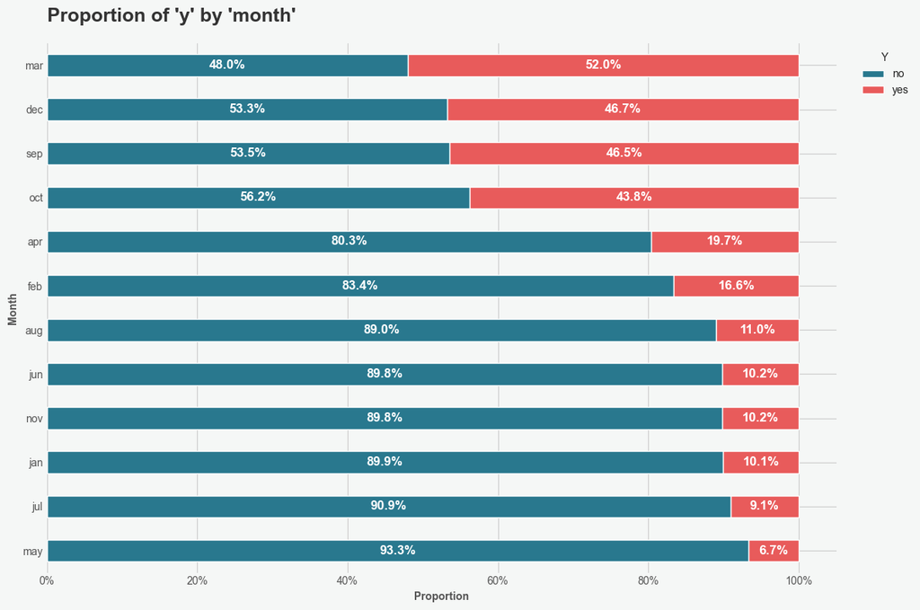

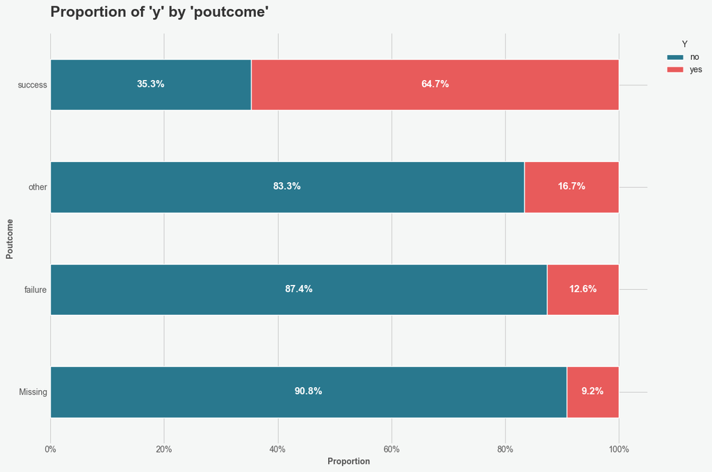

```python
# Observing the relationship between categorical features and the target variable
categorical_features.remove('y')
for feat in df[categorical_features]:
    plot_stacked_bar_percentage(df, feat, 'y')
```

- **Time-Based & Behavioral Features**
  - The `month` variable appears to be a good predictor. There is a clear seasonal pattern, where campaings in March, September, October and December are wildly successful. May and July, on the other hand, presented worse outcomes.
  - The previous campaign outcome (`poutcome`) is also a powerful indicator. Clients with a prior '*success*' are more likely to subscribe again.
- **Demographics & Occupation**
  - The `job` type reveals interesting patterns as well. Those labeled as `student` and `retired` appears to have the highest propensity to subscribe. On the other hand, `blue-collar` workers and `entrepreneur` were the least likely.
  - A similar trend can be observed for `marital` status and `education`. `Single` clients and those with `tertiary` (i.e., higher education) had slightly higher success rates.
- **Financial Status**
  - Binary categorical features (`housing`, `loan`, and `default`) also show interesting insights. Subscriptions are more common proportionally among those with no existing housing loan, no personal loan, and no credit default. This could indicate that clients with fewer financial liabilities are a more receptive audience for this product.

### Continuous Features

Now we'll turn our attention to the continuous features. We will analyze their distributions and explore how they relate to the subscription outcome. We will also use a correlation matrix to assess any relationships between the numerical features themselves.

```python
# EDA Plots
def plot_hist_box(df, feat):
    """
    This function plots a histogram and a box plot side-by-side
    for a given continuous feature.
    """
    fig, axes = plt.subplots(
        1,2,
        figsize=(14, 6),
        facecolor='#f5f7f6',
        gridspec_kw={'width_ratios': [1, 4]}
    )

    fig.suptitle(
        f'Distribution of {feat}',
        fontsize=18, fontweight='bold', color='#333333', y=1.05
    )
    sns.boxplot(
        y=df[feat],
        ax=axes[0],
        color='#D32F2F',
        boxprops=dict(alpha=.7),
        medianprops=dict(color='white', linewidth=2)
    )
    axes[0].set_facecolor('#f5f7f6')
    axes[0].set_title('Box Plot', fontsize=14, fontweight='bold', color='#555555')
    axes[0].set_ylabel(feat.title(), fontweight='bold', color='#555555')
    axes[0].set_xlabel('')

    sns.histplot(
        data=df,
        x=feat,
        ax=axes[1],
        color='#1976D2',
        kde=True,
        alpha=0.6,
        edgecolor='w',
        linewidth=1.5
    )
    axes[1].set_facecolor('#f5f7f6')
    axes[1].set_title('Histogram & Density Curve (KDE)', fontsize=14, fontweight='bold', color='#555555')
    axes[1].set_xlabel(feat.title(), fontweight='bold', color='#555555')
    axes[1].set_ylabel('Frequency', fontweight='bold', color='#555555')

    sns.despine(left=True, bottom=True)
    plt.tight_layout(rect=[0,0,1,0.96])
    plt.show()
```

```python
# EDA plots
def plot_kde_by_target(df, cont_feat, target):
    """
    This function plots overlapping KDEs for a continuous feature,
    separated by the binary target variable.
    """
    palette = {
        'no': '#29788E',
        'yes': '#E85B5B'
    }

    plt.style.use('seaborn-v0_8-whitegrid')
    fig, ax = plt.subplots(figsize=(12, 7))
    fig.set_facecolor('#f5f7f6')
    ax.set_facecolor('#f5f7f6')

    sns.kdeplot(
        data=df,
        x=cont_feat,
        hue=target,
        fill=True,
        common_norm=False,
        alpha=0.6,
        palette=palette,
        linewidth=2.5,
        ax=ax
    )

    ax.set_title(
        f"Distribution of '{cont_feat}' by '{target}'",
        fontsize=18, fontweight='bold', pad=20, loc='left', color='#333333'
    )

    ax.set_xlabel(
        cont_feat.title(), fontweight='bold', color='#555555'
    )
    ax.set_ylabel(
        'Density', fontweight='bold', color='#555555'
    )

    sns.despine(left=True, bottom=True)
    plt.tight_layout()
    plt.show()
```

```python
# EDA Plots
def plot_correlation_heatmap(df):
    """
    This function plots a correlation heatmap for numerical features.
    """

    corr = df.corr(numeric_only=True).round(2)

    mask = np.triu(np.ones_like(corr, dtype=bool))

    fig, ax = plt.subplots(figsize=(10, 8))
    fig.set_facecolor('#f5f7f6')

    sns.heatmap(
        corr,
        mask=mask,
        annot=True,
        fmt='.2f',
        cmap='YlOrBr',
        center=0,
        square=True,
        linewidths=.5,
        cbar_kws={"shrink": .8},
        ax=ax
    )

    ax.set_title(
        'Feature Correlation Heatmap',
        fontsize=18, fontweight='bold', pad=20, loc='left', color='#333333'
    )
    plt.xticks(rotation=45, ha='right', fontsize=10, color='#555555')
    plt.yticks(rotation=0, fontsize=10, color='#555555')

    plt.tight_layout()
    plt.show()
```

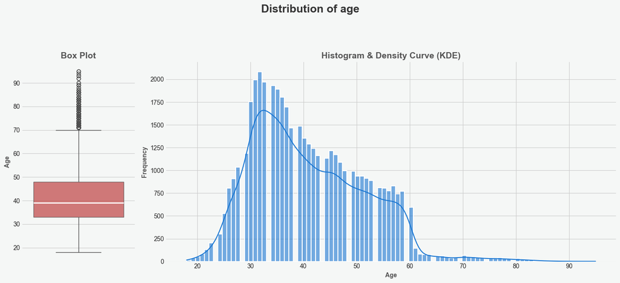

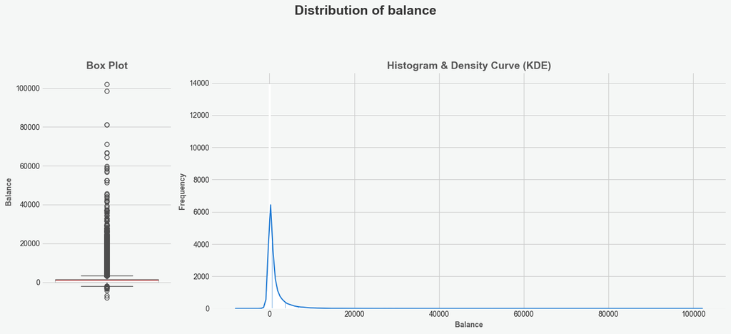

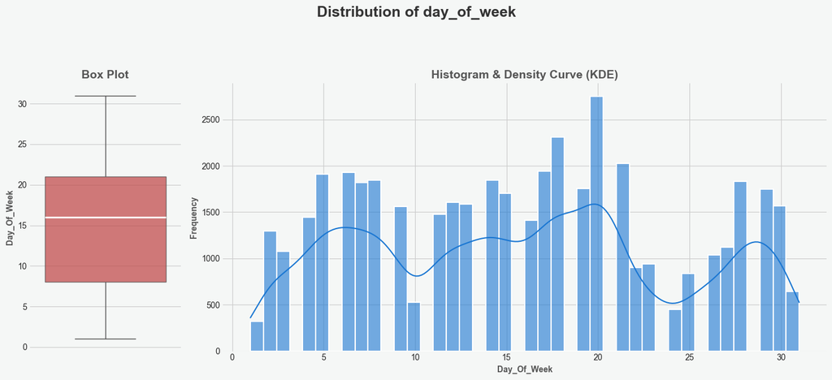

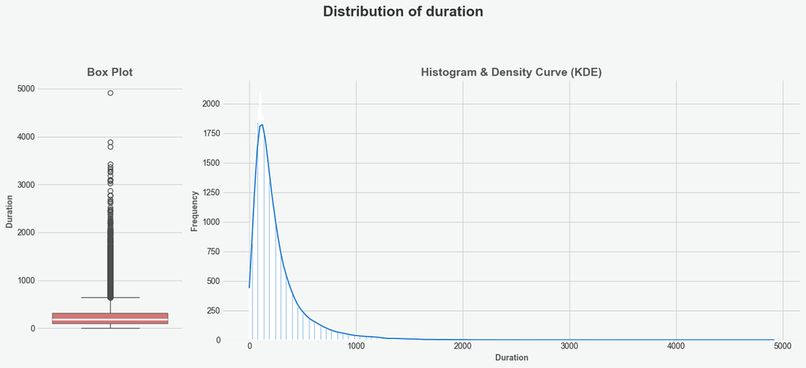

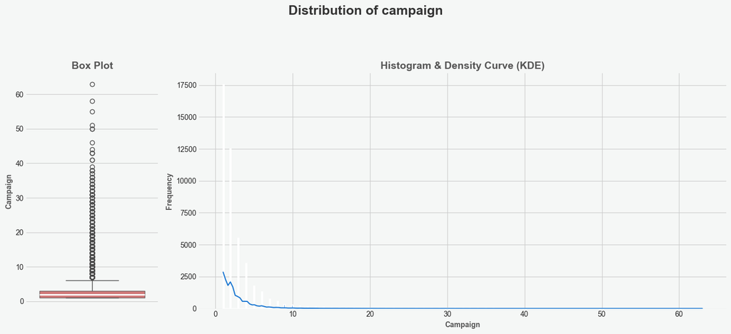

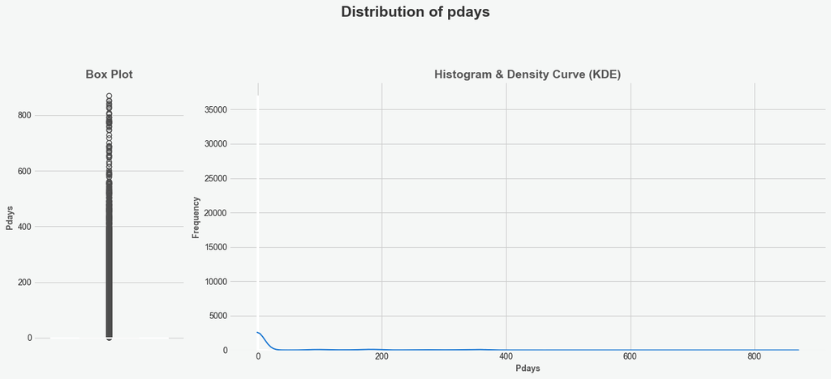

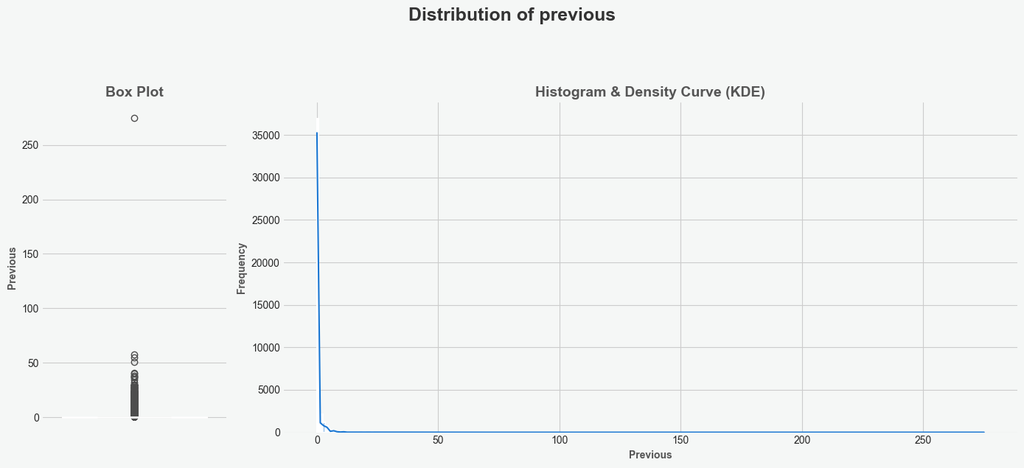

```python
# Plotting Box Plot and Histogram for continuous features
for feat in continuous_features:
    plot_hist_box(df, feat)
```

- **Skewness**
  - The variables `balance`, `duration`, and `campaign` are heavily right-skewed. That means there is a much larger concentration of data points at the lower end with a long tail of extreme, but less frequent, values. For **linear models** (e.g., Support Vector Machines, Logistic Regression) and **distance-based** algorithms (e.g., KMeans), this skew can be problematic.
- **Quasi-Categorical Features**
  - The `pdays` and `previous` features are not truly continuous but behave as *quasi-categorical variables*. Each is dominated by a single value (-1 for `pdays` and 0 for `previous`), which accounts for over 80% of the data. This indicates they should be re-engineered into binary or categorical features rather than being treated as numerical.

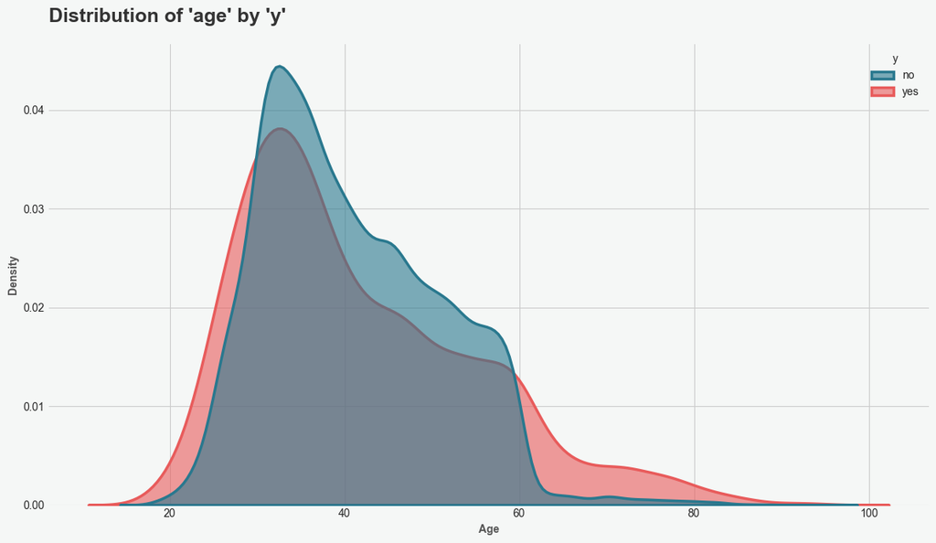

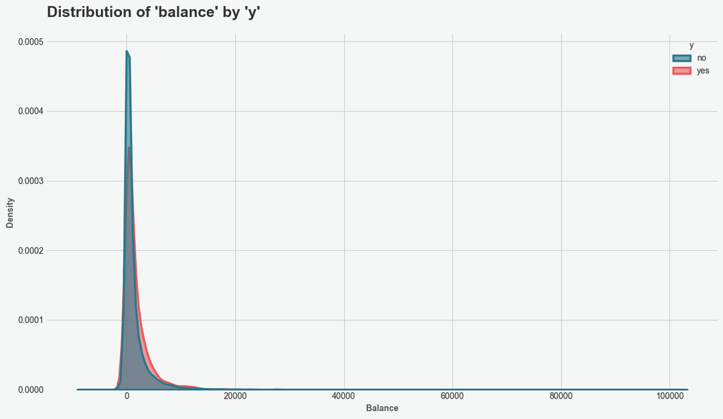

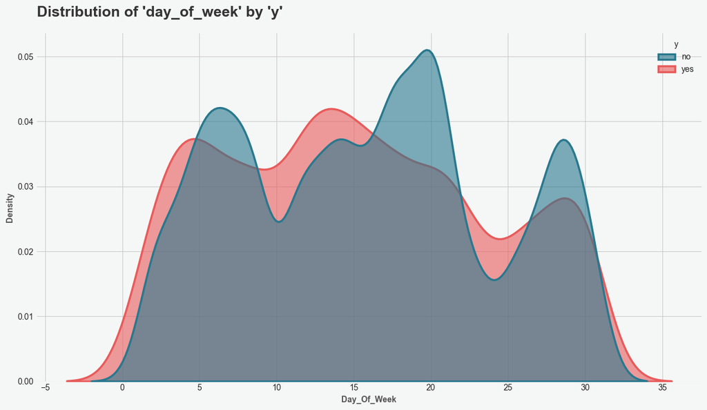

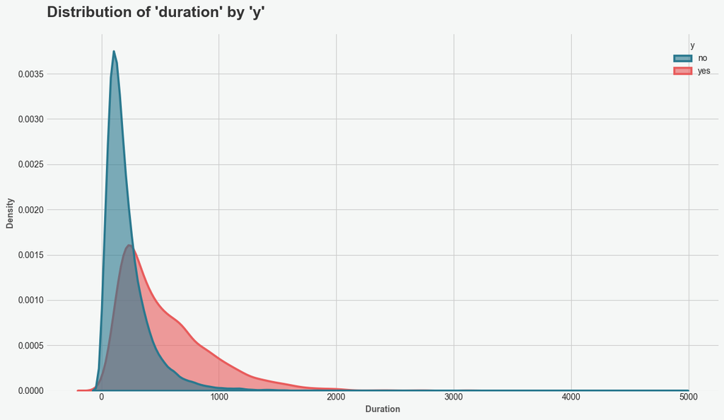

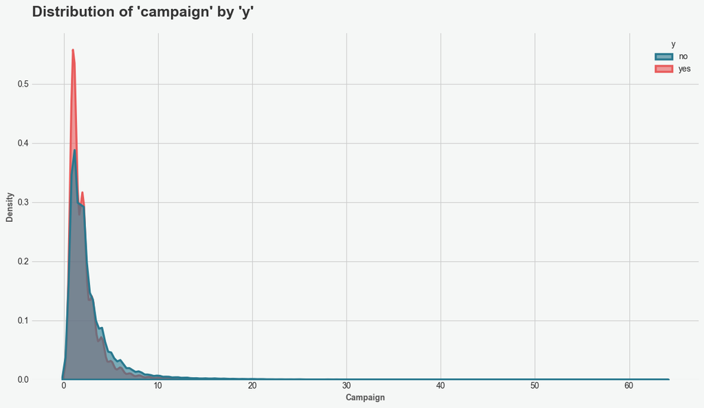

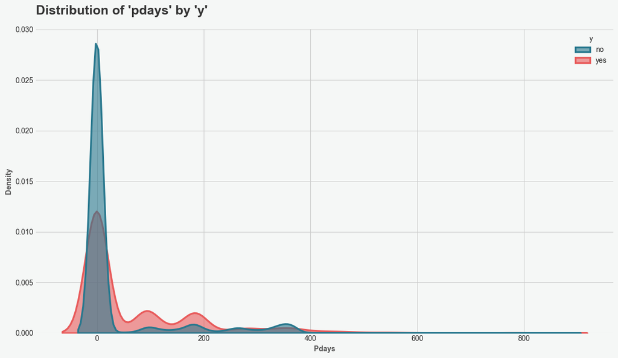

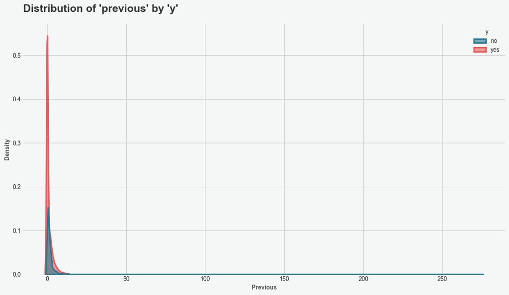

```python
# Plotting KDE plots for continuous features by target variable
for feat in continuous_features:
    plot_kde_by_target(df, feat, 'y')
```

- **Data Leakage**
  - The `duration` of the call is highly correlated with the outcome, with longer calls strongly indicating a subscription. However, we known this is a data leak, since the duration is only known *after* the call is made. We will remove this feature from the dataset before modeling.
- **Behavioral Predictors**
  - The number of contacts (`campaign`) appears to be a relevant predictor. Successful outcomes are heavily concentrated in the **first one or two contacts**. The data clearly shows that repeated contacts lead to diminishing returns, with a high number of calls being strongly associated with a negative outcome.
  - Similarly, prior engagement (`pdays`) is a positive signal. While most clients have never been contacted before (`pdays = -1`), those who *have* been previously contacted show a higher propensity to subscribe.
- **Demographic Insights**
  - The `age` distribution confirms our findings from the `job` analysis. There is a higher likelihood of subscription among clients at the extremes of the age range: **younger clients (typically students)** and **older clients (typically retired)**.

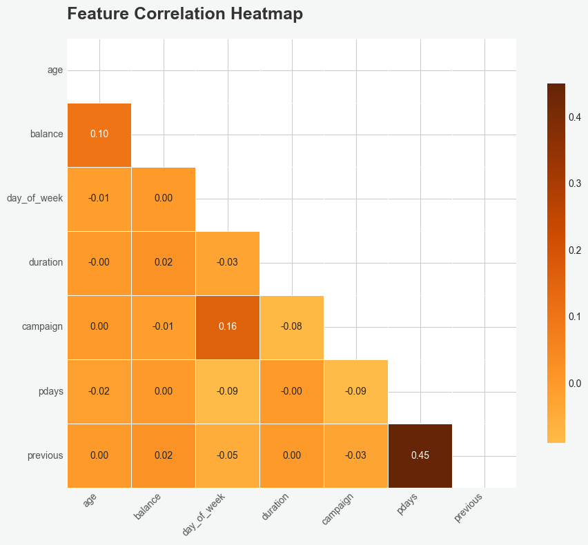

```python
# Plotting correlation heatmap
plot_correlation_heatmap(df)
```

- **Moderate Positive Correlation**
  - The most significant correlation is a moderate positive relationship between `pdays` and `previous`. This is expected, because both features are related to past contact history. If a client has had previous contact (`previous` > 0), then pdays will also have a value other than `-1`. They are measuring a similar underlying concept.
- **Absence of Linear Trends**
  - Overall, the correlation heatmap shows that there are no linear trends among continuous features (e.g., *"as age increases, balance increases*). This lack of strong linear relationships suggest that linear models might struggle to find patterns without a significant level of feature engineering. Non-linear models, like Random Forest or Gradient Boosting, might be able to capture more complex relationships between features.

## Data Pipeline & Preprocessing

In this section, we will start by building a baseline. We will then perform some feature engineering based on our findings and build the data pipeline that will be used to automate and encapsulate all our preprocessing workflow.

### Baseline

Let's start by building a baseline with a simple Logistic Regression model to evaluate performance.  
During our EDA, we uncovered that `poutcome` feature has over 80% of missing data. Our first inclination was to drop this feature, due to a high number of missing data. However, given that this feature appears to have important predictive power (64.7% of clients whose previous marketing campaign was a `success` said `yes` to this current campaign), we might want to test performance of a baseline model **with and without** this feature.  
If including `poutcome` gives us a signifcant performance boost, we will know it is worth it to keep this feature. However, if performance is worse, we will opt for excluding it.

```python
# Creating a copy of the original dataframe for preprocessing and modelling
df_model = df.copy()

# Dropping the 'duration' feature due to data leakage
df_model.drop(columns=['duration'], axis=1, inplace=True)

# Filling missing values in categorical features with 'Unknown'
df_model[categorical_features] = df_model[categorical_features].fillna('unknown')

# Separating features and target variable
X = df_model.drop('y', axis=1)
y = df_model['y'].map({'yes': 1, 'no': 0}) # Encoding target variable as binary

print("--- Features and Target Variable ---")
print("\nFeatures:\n")
print(X.shape)
print('\n')
print(X.head())
print("\nTarget Variable:\n")
print(y.shape)
print('\n')
print(y.head())
print("\n------------------------------------\n")
print("Missing Data Check:\n")
print(df_model.isnull().sum())
print("\n------------------------------------\n")
```

```
--- Features and Target Variable ---

Features:

(45211, 15)


   age           job  marital  education default  balance housing loan  \
0   58    management  married   tertiary      no     2143     yes   no
1   44    technician   single  secondary      no       29     yes   no
2   33  entrepreneur  married  secondary      no        2     yes  yes
3   47   blue-collar  married    unknown      no     1506     yes   no
4   33       unknown   single    unknown      no        1      no   no

   contact  day_of_week month  campaign  pdays  previous poutcome
0  unknown            5   may         1     -1         0  unknown
1  unknown            5   may         1     -1         0  unknown
2  unknown            5   may         1     -1         0  unknown
3  unknown            5   may         1     -1         0  unknown
4  unknown            5   may         1     -1         0  unknown

Target Variable:

(45211,)


0    0
1    0
2    0
3    0
4    0
Name: y, dtype: int64

------------------------------------

Missing Data Check:

age            0
job            0
marital        0
education      0
default        0
balance        0
housing        0
loan           0
contact        0
day_of_week    0
month          0
campaign       0
pdays          0
previous       0
poutcome       0
y              0
dtype: int64

------------------------------------
```

```python
# Splitting the dataset into training and testing sets
X_train, X_test, y_train, y_test = train_test_split(
    X, y, test_size=0.2, random_state=seed, stratify=y)
print("--- Train-Test Split ---\n")
print(f"Training set shape: {X_train.shape}, {y_train.shape}")
print(f"Testing set shape: {X_test.shape}, {y_test.shape}")
```

```
--- Train-Test Split ---

Training set shape: (36168, 15), (36168,)
Testing set shape: (9043, 15), (9043,)
```

```python
# Evaluation function for model performance
def plot_confusion_matrix(y_true, y_pred, model_name):
    """
    This function plots a confusion matrix for the given true and predicted labels.
    """
    cm = confusion_matrix(y_true, y_pred)
    tn, fp, fn, tp = cm.ravel()

    fig, ax = plt.subplots(figsize=(6, 6))
    fig.set_facecolor('#f5f7f6')

    sns.heatmap(
        cm,
        annot=True,
        fmt='d',
        cmap='Blues',
        cbar=False,
        annot_kws={"size": 16},
        ax=ax
    )

    ax.set_title(
        f'Confusion Matrix for {model_name}',
        fontsize=18, fontweight='bold', pad=20, loc='left', color='#333333'
    )
    ax.set_xlabel('Predicted Label', fontweight='bold', color='#555555')
    ax.set_ylabel('True Label', fontweight='bold', color='#555555')

    ax.xaxis.set_ticklabels(['No (0)', 'Yes (1)'])
    ax.yaxis.set_ticklabels(['No (0)', 'Yes (1)'])

    plt.tight_layout()
    plt.show()
```

```
Categorical Features (without 'poutcome'):
 Index(['job', 'marital', 'education', 'default', 'housing', 'loan', 'contact',
       'month'],
      dtype='object')

Numerical Features (without 'poutcome'):
 Index(['age', 'balance', 'day_of_week', 'campaign', 'pdays', 'previous'], dtype='object')

------------------------------------


Preprocessor (without 'poutcome'):
 ColumnTransformer(transformers=[('cat', OneHotEncoder(handle_unknown='ignore'),
                                 Index(['job', 'marital', 'education', 'default', 'housing', 'loan', 'contact',
       'month'],
      dtype='object')),
                                ('num', PowerTransformer(),
                                 Index(['age', 'balance', 'day_of_week', 'campaign', 'pdays', 'previous'], dtype='object'))])

------------------------------------


Pipeline (without 'poutcome'):
 Pipeline(steps=[('preprocessor',
                 ColumnTransformer(transformers=[('cat',
                                                  OneHotEncoder(handle_unknown='ignore'),
                                                  Index(['job', 'marital', 'education', 'default', 'housing', 'loan', 'contact',
       'month'],
      dtype='object')),
                                                 ('num', PowerTransformer(),
                                                  Index(['age', 'balance', 'day_of_week', 'campaign', 'pdays', 'previous'], dtype='object'))])),
                ('smote', SMOTE(random_state=42)),
                ('classifier',
                 LogisticRegression(class_weight='balanced', max_iter=1000,
                                    random_state=42))])

------------------------------------


Categorical Features (with 'poutcome'):
```

[output cut: 48 more lines]

```
    accuracy                           0.71      9043
   macro avg       0.59      0.70      0.58      9043
weighted avg       0.86      0.71      0.76      9043


Classification Report (with 'poutcome'):

              precision    recall  f1-score   support

          no       0.94      0.77      0.85      7985
         yes       0.27      0.63      0.38      1058

    accuracy                           0.76      9043
   macro avg       0.60      0.70      0.61      9043
weighted avg       0.86      0.76      0.79      9043
```

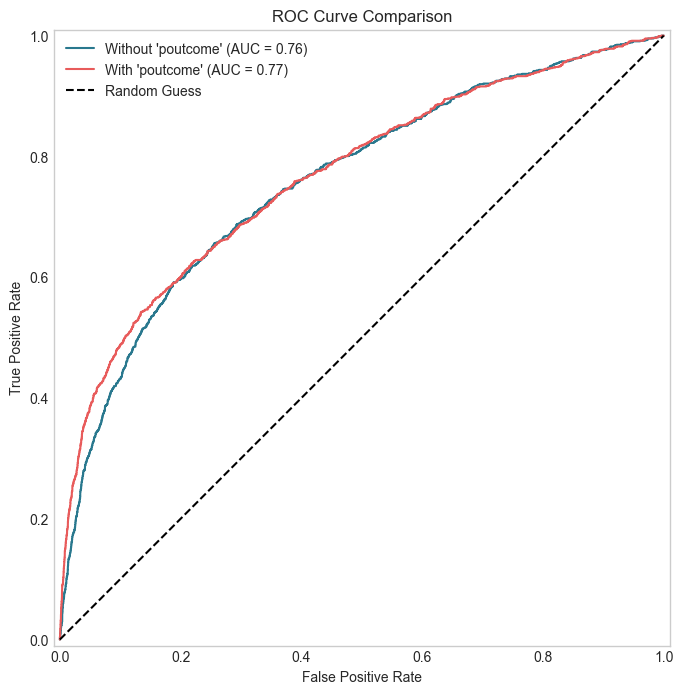

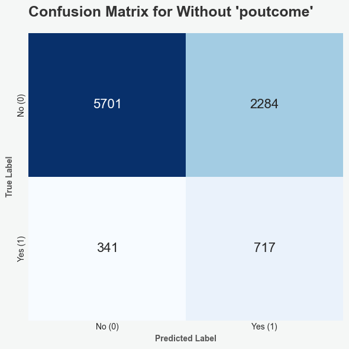

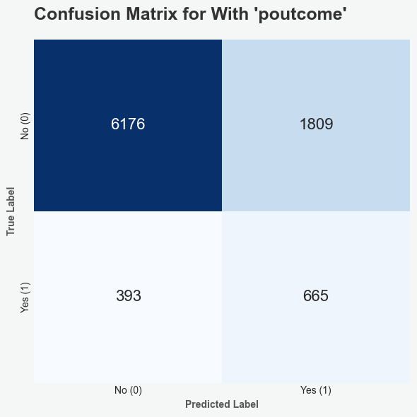

```
Performance Comparison DataFrame:
```

|  | Model | Precision | Recall | F1-Score | ROC AUC |
| --- | --- | --- | --- | --- | --- |
| 0 | Without 'poutcome' | 0.24 | 0.68 | 0.35 | 0.76 |
| 1 | With 'poutcome' | 0.27 | 0.63 | 0.38 | 0.77 |

```python
# --- Experimenting Baseline Model Without `poutcome` ---
# Dropping `poutcome` feature
X_train_no_poutcome = X_train.drop(columns=['poutcome'], axis=1)
X_test_no_poutcome = X_test.drop(columns=['poutcome'], axis=1)

# Identifying categorical and numerical features for preprocessing
categorical_features_no_poutcome = X_train_no_poutcome.select_dtypes(include=['object']).columns
numerical_features_no_poutcome = X_train_no_poutcome.select_dtypes(include=np.number).columns
print("\nCategorical Features (without 'poutcome'):\n", categorical_features_no_poutcome)
print("\nNumerical Features (without 'poutcome'):\n", numerical_features_no_poutcome)
print("\n------------------------------------\n")

# Creating preprocessor for encoding categorical features and scaling numerical features
preprocessor_no_poutcome = ColumnTransformer(
    transformers=[
        ('cat', OneHotEncoder(handle_unknown='ignore'), categorical_features_no_poutcome),
        ('num', PowerTransformer(method='yeo-johnson'), numerical_features_no_poutcome)
    ])
print("\nPreprocessor (without 'poutcome'):\n", preprocessor_no_poutcome)
print("\n------------------------------------\n")

# Creating a pipeline with SMOTE and Logistic Regression
pipeline_no_poutcome = ImbPipeline(steps=[
    ('preprocessor', preprocessor_no_poutcome),
    ('smote', SMOTE(random_state=seed)),
    ('classifier', LogisticRegression(class_weight='balanced', random_state=seed, max_iter=1000))
])
print("\nPipeline (without 'poutcome'):\n", pipeline_no_poutcome)
print("\n------------------------------------\n")

# Training and evaluating the model without `poutcome`
pipeline_no_poutcome.fit(X_train_no_poutcome, y_train)
y_pred_no_poutcome = pipeline_no_poutcome.predict(X_test_no_poutcome)
y_proba_no_poutcome = pipeline_no_poutcome.predict_proba(X_test_no_poutcome)[:, 1]

# --- Experimenting Baseline Model With `poutcome` ---
# Identifying categorical and numerical features for preprocessing
categorical_features_with_poutcome = X_train.select_dtypes(include=['object']).columns
numerical_features_with_poutcome = X_train.select_dtypes(include=np.number).columns
print("\nCategorical Features (with 'poutcome'):\n", categorical_features_with_poutcome)
print("\nNumerical Features (with 'poutcome'):\n", numerical_features_with_poutcome)
print("\n------------------------------------\n")

# Creating preprocessor for encoding categorical features and scaling numerical features
preprocessor_with_poutcome = ColumnTransformer(
    transformers=[
        ('cat', OneHotEncoder(handle_unknown='ignore'), categorical_features_with_poutcome),
        ('num', PowerTransformer(method='yeo-johnson'), numerical_features_with_poutcome)
    ])
print("\nPreprocessor (with 'poutcome'):\n", preprocessor_with_poutcome)
print("\n------------------------------------\n")

# Creating a pipeline with SMOTE and Logistic Regression
pipeline_with_poutcome = ImbPipeline(steps=[
    ('preprocessor', preprocessor_with_poutcome),
    ('smote', SMOTE(random_state=seed)),
    ('classifier', LogisticRegression(class_weight='balanced', random_state=seed, max_iter=1000))
])
print("\nPipeline (with 'poutcome'):\n", pipeline_with_poutcome)
print("\n------------------------------------\n")

# Training and evaluating the model with `poutcome`
pipeline_with_poutcome.fit(X_train, y_train)
y_pred_with_poutcome = pipeline_with_poutcome.predict(X_test)
y_proba_with_poutcome = pipeline_with_poutcome.predict_proba(X_test)[:, 1]

# --- Performance Comparison ---
print("\n--- Model Performance Comparison ---\n")
print("\nClassification Report (without 'poutcome'):\n")
print(classification_report(y_test, y_pred_no_poutcome, target_names=['no', 'yes']))
print("\nClassification Report (with 'poutcome'):\n")
print(classification_report(y_test, y_pred_with_poutcome, target_names=['no', 'yes']))

# Plotting ROC Curves for both models
fig, ax = plt.subplots(figsize=(8, 8))
RocCurveDisplay.from_predictions(y_test, y_proba_no_poutcome, name="Without 'poutcome'", color='#29788E', ax=ax)
RocCurveDisplay.from_predictions(y_test, y_proba_with_poutcome, name="With 'poutcome'", color='#E85B5B', ax=ax)
ax.plot([0, 1], [0, 1], 'k--', label='Random Guess')
ax.set_title('ROC Curve Comparison')
ax.set_xlabel('False Positive Rate')
ax.set_ylabel('True Positive Rate')
ax.legend()
ax.grid()
plt.show()

# Plotting Confusion Matrices for both models
plot_confusion_matrix(y_test, y_pred_no_poutcome, "Without 'poutcome'")
plot_confusion_matrix(y_test, y_pred_with_poutcome, "With 'poutcome'")

# Building a Comparison Dataframe
metrics = {
    'Model': ["Without 'poutcome'", "With 'poutcome'"],
    'Precision': [
        precision_score(y_test, y_pred_no_poutcome),
        precision_score(y_test, y_pred_with_poutcome)
    ],
    'Recall': [
        recall_score(y_test, y_pred_no_poutcome),
        recall_score(y_test, y_pred_with_poutcome)
    ],
    'F1-Score': [
        f1_score(y_test, y_pred_no_poutcome),
        f1_score(y_test, y_pred_with_poutcome)
    ],
    'ROC AUC': [
        roc_auc_score(y_test, y_proba_no_poutcome),
        roc_auc_score(y_test, y_proba_with_poutcome)
    ]
}
comparison_df = pd.DataFrame(metrics)
print("\nPerformance Comparison DataFrame:\n")
display(comparison_df.style.format({'Precision': '{:.2f}', 'Recall': '{:.2f}', 'F1-Score': '{:.2f}', 'ROC AUC': '{:.2f}'}))
```

- **Performance Evaluation**
  - Although the improvement is not massive, the model that includes the `poutcome` feature demonstrated superior performance on our key metrics. It achieved a higher **F1-Score (0.38 vs. 0.35)**, which indicates a better balance between Precision and Recall. While its Recall was slightly lower, its **Precision** was higher, resulting in significantly fewer False Positive errors (1,809 vs. 2,284).
- **Business POV**
  - From a business perspective, an effective marketing campaign must balance two objectives: maximizing the number of successful sales (**Recall**) while minimizing resources spent on uninterested clients (**Precision**). The **F1-Score** is the ideal metric for this scenario as it measures the overall effectiveness of the model's generated call list by finding a harmony between these two goals. Since the model *with* `poutcome` achieved a higher F1-Score, it provides more business value. Therefore, we will keep this feature for our final model.

### Feature Engineering

We will maintain the `poutcome` feature in the dataset. In this section, we will fill in missing data with the `unknown` label across categories. We will also drop the `duration` feature due to data leakage and re-engineer quasi-categorical features.

```python
# Creating a copy of the model dataframe for feature engineering
df_engineered = df.copy()

# Dropping the `duration` feature due to data leakage
df_engineered.drop(columns=['duration'], axis=1, inplace=True)

# Replacing missing values with `unknown`
df_engineered[categorical_features] = df_engineered[categorical_features].fillna('unknown')

print("\n--- Initial Cleaning Complete ---\n")
print("Feature `duration` dropped and NaNs filled with 'unknown'.\n")
print("Original Dataframe:\n")
display(df.head(5))
print("\nEngineered Dataframe:\n")
display(df_engineered.head(5))
print("\n------------------------------------\n")
```

```
--- Initial Cleaning Complete ---

Feature `duration` dropped and NaNs filled with 'unknown'.

Original Dataframe:
```

|  | age | job | marital | education | default | balance | housing | loan | contact | day_of_week | month | duration | campaign | pdays | previous | poutcome | y |
| --- | --- | --- | --- | --- | --- | --- | --- | --- | --- | --- | --- | --- | --- | --- | --- | --- | --- |
| 0 | 58 | management | married | tertiary | no | 2143 | yes | no | NaN | 5 | may | 261 | 1 | -1 | 0 | NaN | no |
| 1 | 44 | technician | single | secondary | no | 29 | yes | no | NaN | 5 | may | 151 | 1 | -1 | 0 | NaN | no |
| 2 | 33 | entrepreneur | married | secondary | no | 2 | yes | yes | NaN | 5 | may | 76 | 1 | -1 | 0 | NaN | no |
| 3 | 47 | blue-collar | married | NaN | no | 1506 | yes | no | NaN | 5 | may | 92 | 1 | -1 | 0 | NaN | no |
| 4 | 33 | NaN | single | NaN | no | 1 | no | no | NaN | 5 | may | 198 | 1 | -1 | 0 | NaN | no |

```
Engineered Dataframe:
```

|  | age | job | marital | education | default | balance | housing | loan | contact | day_of_week | month | campaign | pdays | previous | poutcome | y |
| --- | --- | --- | --- | --- | --- | --- | --- | --- | --- | --- | --- | --- | --- | --- | --- | --- |
| 0 | 58 | management | married | tertiary | no | 2143 | yes | no | unknown | 5 | may | 1 | -1 | 0 | unknown | no |
| 1 | 44 | technician | single | secondary | no | 29 | yes | no | unknown | 5 | may | 1 | -1 | 0 | unknown | no |
| 2 | 33 | entrepreneur | married | secondary | no | 2 | yes | yes | unknown | 5 | may | 1 | -1 | 0 | unknown | no |
| 3 | 47 | blue-collar | married | unknown | no | 1506 | yes | no | unknown | 5 | may | 1 | -1 | 0 | unknown | no |
| 4 | 33 | unknown | single | unknown | no | 1 | no | no | unknown | 5 | may | 1 | -1 | 0 | unknown | no |

```python
# Reviewing descriptive statistics for `pdays` and `previous` features
df[['pdays', 'previous']].describe().T
```

|  | count | mean | std | min | 25% | 50% | 75% | max |
| --- | --- | --- | --- | --- | --- | --- | --- | --- |
| pdays | 45211.0 | 40.197828 | 100.128746 | -1.0 | -1.0 | -1.0 | -1.0 | 871.0 |
| previous | 45211.0 | 0.580323 | 2.303441 | 0.0 | 0.0 | 0.0 | 0.0 | 275.0 |

- **EDA Insights**
  - During EDA, we observed that `pdays` and `previous` features have an overwhelming number of instances at the same value (`-1` and `0`). Essentially, these features don't really behave that much as continuous features.
  - In an attempt to improve performance, we will engineer these features by transforming them into **binary features** and then dropping the original columns.
- **New Features**
  - Instead of `pdays`, we will create a new feature called `was_previously_contacted` where values other than `-1` will be labeled as `yes`.
  - Likewise, we will transform the `previous` feature into a feature called `had_previous_contact`, where values other than `0` will be labeled as `yes`.

```python
# Transforming `pdays` and `previous` into binary features
df_engineered['was_previously_contacted'] = np.where(df_engineered['pdays'] != -1, 'yes', 'no')
df_engineered['had_previous_contact'] = np.where(df_engineered['previous'] != 0, 'yes', 'no')
df_engineered.drop(columns=['pdays', 'previous'], axis=1, inplace=True)
print("\n--- Engineering `pdays` and `previous` into binary features and dropping original columns ---\n")
print("Original Dataframe:\n")
display(df[['pdays', 'previous']].head(5))
print("\nEngineered Dataframe:\n")
display(df_engineered[['was_previously_contacted', 'had_previous_contact']].head(5))
print("\n------------------------------------\n")
```

```
--- Engineering `pdays` and `previous` into binary features and dropping original columns ---

Original Dataframe:
```

|  | pdays | previous |
| --- | --- | --- |
| 0 | -1 | 0 |
| 1 | -1 | 0 |
| 2 | -1 | 0 |
| 3 | -1 | 0 |
| 4 | -1 | 0 |

```
Engineered Dataframe:
```

|  | was_previously_contacted | had_previous_contact |
| --- | --- | --- |
| 0 | no | no |
| 1 | no | no |
| 2 | no | no |
| 3 | no | no |
| 4 | no | no |

- **Dealing with Mislabeled Features**
  - Our EDA also revealed that the feature `day_of_week` is misleading, as it clearly refers to the day of the month. We will rename it to a more accurate designation. We will also stop treating it as a continuous feature and normalizing it within the pipeline. Instead, we will handle it as a **categorical feature**. The idea is to convert it to a string type and allow the model to learn the importance of specific days without assuming any ordered relationship between them.

```python
# Renaming `day_of_week` to `day_of_month` and treating it as a categorical feature
df_engineered.rename(columns={'day_of_week': 'day_of_month'}, inplace=True)
df_engineered['day_of_month'] = df_engineered['day_of_month'].astype('object')
print("\n--- Renaming `day_of_week` to `day_of_month` and converting to categorical feature ---\n")
print("Original Dataframe:\n")
print("Data Type:", df['day_of_week'].dtype)
display(df[['day_of_week']].head(5))
print("\nEngineered Dataframe:\n")
print("Data Type:", df_engineered['day_of_month'].dtype)
display(df_engineered[['day_of_month']].head(5))
print("\n------------------------------------\n")
```

```
--- Renaming `day_of_week` to `day_of_month` and converting to categorical feature ---

Original Dataframe:

Data Type: int64
```

|  | day_of_week |
| --- | --- |
| 0 | 5 |
| 1 | 5 |
| 2 | 5 |
| 3 | 5 |
| 4 | 5 |

```
Engineered Dataframe:

Data Type: object
```

|  | day_of_month |
| --- | --- |
| 0 | 5 |
| 1 | 5 |
| 2 | 5 |
| 3 | 5 |
| 4 | 5 |

Before moving on to the next phase, we can run a quick sanity check by using our `describe_df` function to see if the post-engineered dataframe is how we initially planned.

```python
# Checking the engineered dataframe
describe_df(df_engineered)
```

```
DataFrame shape: (45211, 16)

45,211 samples

16 attributes

Categorical Features:
job, marital, education, default, housing, loan, contact, day_of_month, month, poutcome, y, was_previously_contacted, had_previous_contact

Continuous Features:
age, balance, campaign

Binary (0 or 1) Features:
None

Data Types:
age                          int64
job                         object
marital                     object
education                   object
default                     object
balance                      int64
housing                     object
loan                        object
contact                     object
day_of_month                object
month                       object
campaign                     int64
poutcome                    object
y                           object
was_previously_contacted    object
had_previous_contact        object
dtype: object

Missing Data Percentage:
age                         0.0%
job                         0.0%
marital                     0.0%
education                   0.0%
default                     0.0%
```

[output cut: 21 more lines]

```
marital                      3
contact                      3
default                      2
housing                      2
loan                         2
y                            2
was_previously_contacted     2
had_previous_contact         2
dtype: int64

Features with Zero Variance: None

Features with Negative Values: balance

Statistical Summary:
```

|  | count | mean | std | min | 25% | 50% | 75% | max |
| --- | --- | --- | --- | --- | --- | --- | --- | --- |
| age | 45211.0 | 40.936210 | 10.618762 | 18.0 | 33.0 | 39.0 | 48.0 | 95.0 |
| balance | 45211.0 | 1362.272058 | 3044.765829 | -8019.0 | 72.0 | 448.0 | 1428.0 | 102127.0 |
| campaign | 45211.0 | 2.763841 | 3.098021 | 1.0 | 1.0 | 2.0 | 3.0 | 63.0 |

```
DataFrame Head:
```

|  | age | job | marital | education | default | balance | housing | loan | contact | day_of_month | month | campaign | poutcome | y | was_previously_contacted | had_previous_contact |
| --- | --- | --- | --- | --- | --- | --- | --- | --- | --- | --- | --- | --- | --- | --- | --- | --- |
| 0 | 58 | management | married | tertiary | no | 2143 | yes | no | unknown | 5 | may | 1 | unknown | no | no | no |
| 1 | 44 | technician | single | secondary | no | 29 | yes | no | unknown | 5 | may | 1 | unknown | no | no | no |
| 2 | 33 | entrepreneur | married | secondary | no | 2 | yes | yes | unknown | 5 | may | 1 | unknown | no | no | no |
| 3 | 47 | blue-collar | married | unknown | no | 1506 | yes | no | unknown | 5 | may | 1 | unknown | no | no | no |
| 4 | 33 | unknown | single | unknown | no | 1 | no | no | unknown | 5 | may | 1 | unknown | no | no | no |

```
DataFrame Tail:
```

|  | age | job | marital | education | default | balance | housing | loan | contact | day_of_month | month | campaign | poutcome | y | was_previously_contacted | had_previous_contact |
| --- | --- | --- | --- | --- | --- | --- | --- | --- | --- | --- | --- | --- | --- | --- | --- | --- |
| 45206 | 51 | technician | married | tertiary | no | 825 | no | no | cellular | 17 | nov | 3 | unknown | yes | no | no |
| 45207 | 71 | retired | divorced | primary | no | 1729 | no | no | cellular | 17 | nov | 2 | unknown | yes | no | no |
| 45208 | 72 | retired | married | secondary | no | 5715 | no | no | cellular | 17 | nov | 5 | success | yes | yes | yes |
| 45209 | 57 | blue-collar | married | secondary | no | 668 | no | no | telephone | 17 | nov | 4 | unknown | no | no | no |
| 45210 | 37 | entrepreneur | married | secondary | no | 2971 | no | no | cellular | 17 | nov | 2 | other | no | yes | yes |